# Organic Matter Decomposition Experiment Protocol

Ranae Dietzel

July 22, 2016

One subplot will be established in each continuous corn, fertilized prairie, and prairie plot. Subplots will be approximately 6 feet from the south and west borders. Subplots will be 5’ x 5’.

In the prairie treatments, each subplot will be created by first cutting down the existing vegetation using a weedeater and/or pruning shears. Vegetation will be allowed to grow back to ~ 8" then sprayed with glyphosate, then sprayed with glyphosate again after a couple days. Two soil cores will be taken to a 1 m depth in each subplot. The Giddings will also be used to install ECH2O temp and moisture sensors at 7.5, 30, 60, and as long as my arm cm depths. Subplots will then be covered with landscaping cloth, secured by edging that will go as deep as we can get it. Corn plots will be similar and span three rows, with the sampling focused on the middle row.

Two cores will be taken at time 0, a few days after the last application of RoundUp. Cores will be split into 5 depth increments by centimeters – 0-20, 20-40, 40-60, 60-80, 80-100 and bagged in the field. Bags will be weighed for bulk density and root-free soil will be removed from the samples for analysis of moisture content (bulk density), organic C, total N, and POM. The remainder of the sample will be elutriated and processed for root biomass. Root will also be processed for C, N, and possibly some other components.

### Experimental design

#### S is sensors, 4 cores in 2016, 2 in 2017, 2 in 2018

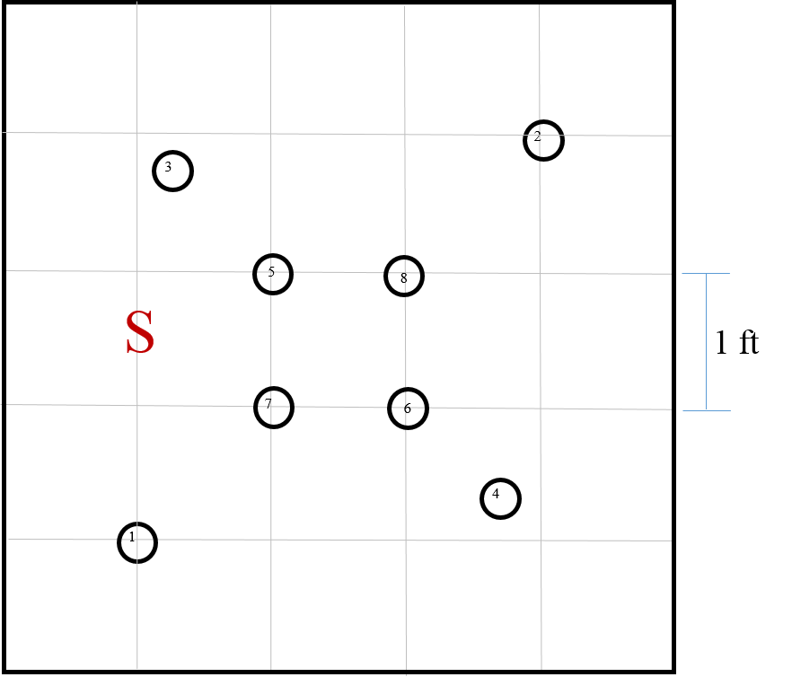

#### S is sensors, green is corn rows 4 cores in 2016, 2 in 2017, 2 in 2018

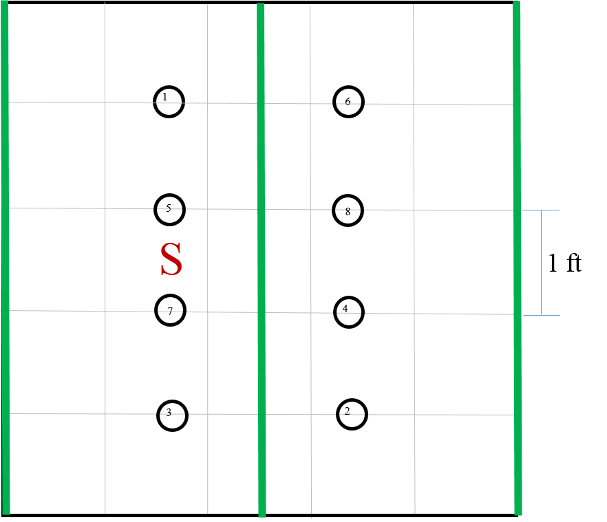

#### Placement within plots

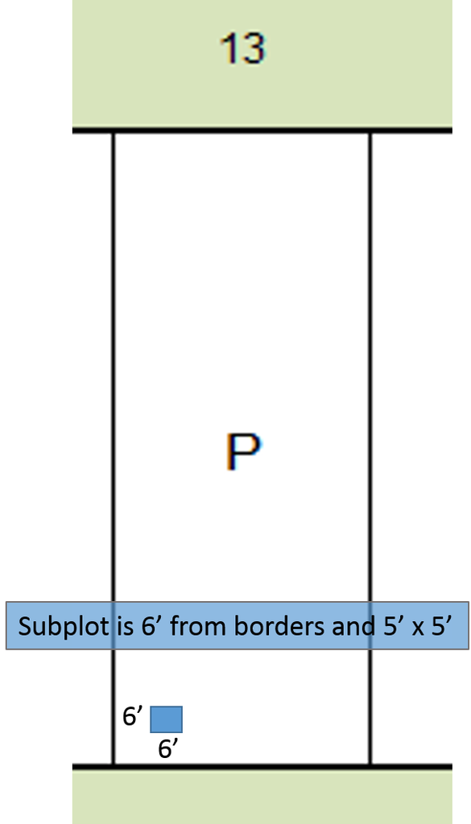

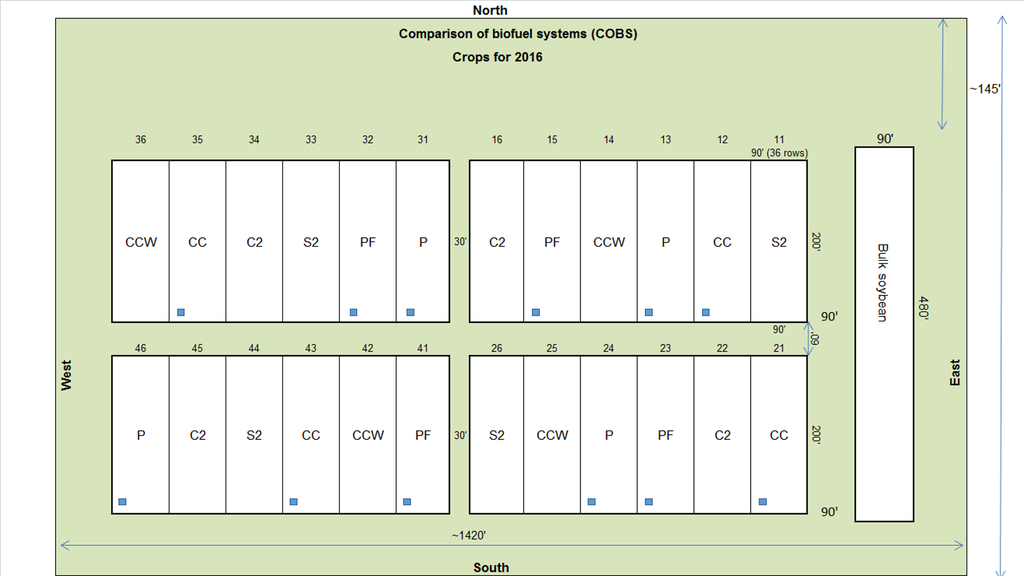